# Shiny Application and Reproducible Pitch

December 6, 2016

## Intruduction of Project

In this progect, the R Markdown presentation is used for my presentation. The data set, mtcars, is use for the analysis. I use the linear regression model which created in my regression course project.

This model include dependent variable MPG (miles per gallon), predictors am (automatic or manual transmission), cyl (car cylinder numbers), hp (car horse power), and wt (car weight in 1000lb). I use sliders for continue variables (hp and wt) and pull down menu for categorical variables (am and cyl) for prediction needs.

The red ponits on 3D graph are original data points from data set and the blue point is the MPG prediction for giving predictors.

## User instruction

- Select Car Weight by moving the first slider
- Select car horse power by moving the second slider
- select car type from the first pull down menu
- select car cylinder from the second pull down menu
- submit your selection by pushing the submit button
- watch the blue predicted point moving

## Data set of mtcars

```
## 'data.frame':    32 obs. of  11 variables:
##  $ mpg : num  21 21 22.8 21.4 18.7 18.1 14.3 24.4 22.8 19.2 ...
##  $ cyl : num  6 6 4 6 8 6 8 4 4 6 ...
##  $ disp: num  160 160 108 258 360 ...
##  $ hp  : num  110 110 93 110 175 105 245 62 95 123 ...
##  $ drat: num  3.9 3.9 3.85 3.08 3.15 2.76 3.21 3.69 3.92 3.92 ...
##  $ wt  : num  2.62 2.88 2.32 3.21 3.44 ...
##  $ qsec: num  16.5 17 18.6 19.4 17 ...
##  $ vs  : num  0 0 1 1 0 1 0 1 1 1 ...
##  $ am  : num  1 1 1 0 0 0 0 0 0 0 ...
##  $ gear: num  4 4 4 3 3 3 3 4 4 4 ...
##  $ carb: num  4 4 1 1 2 1 4 2 2 4 ...
```

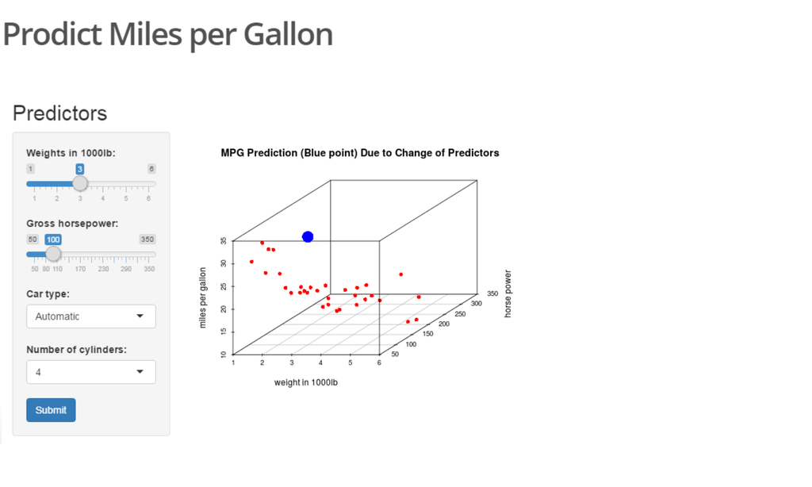